# Explore the Red Wine Quality by Niraj Patel

Let us explore other relationship between other variables as well:

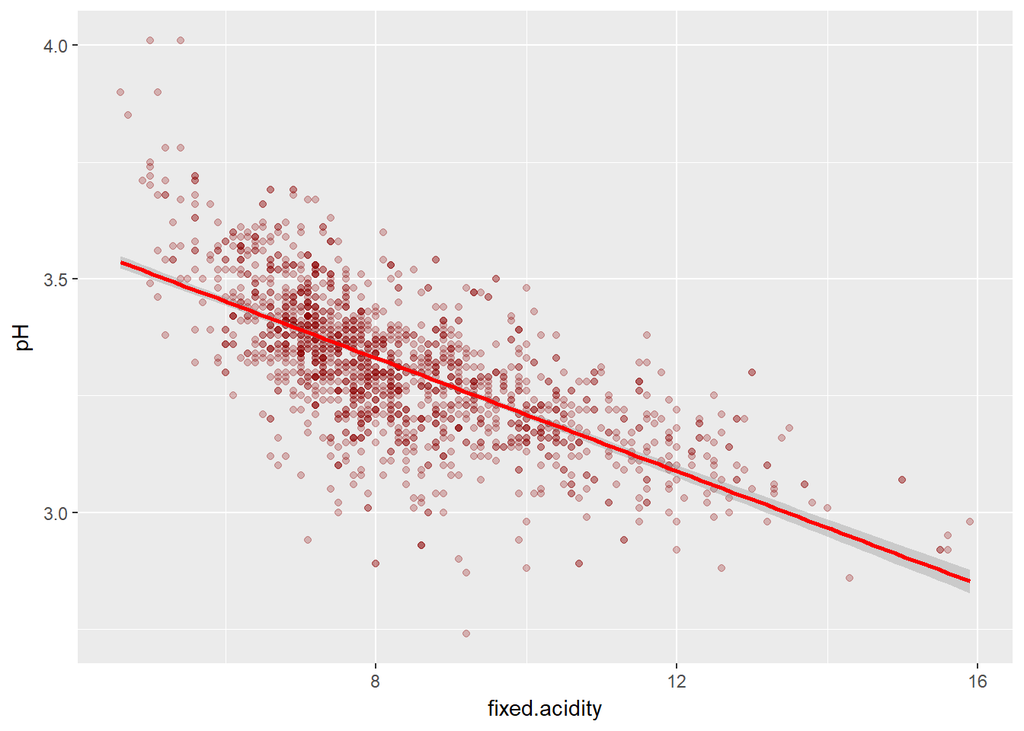

We can infer from that fixd acity and pH are negatively corelated. with the increase in fixed acidity, the pH value starts decreasing.

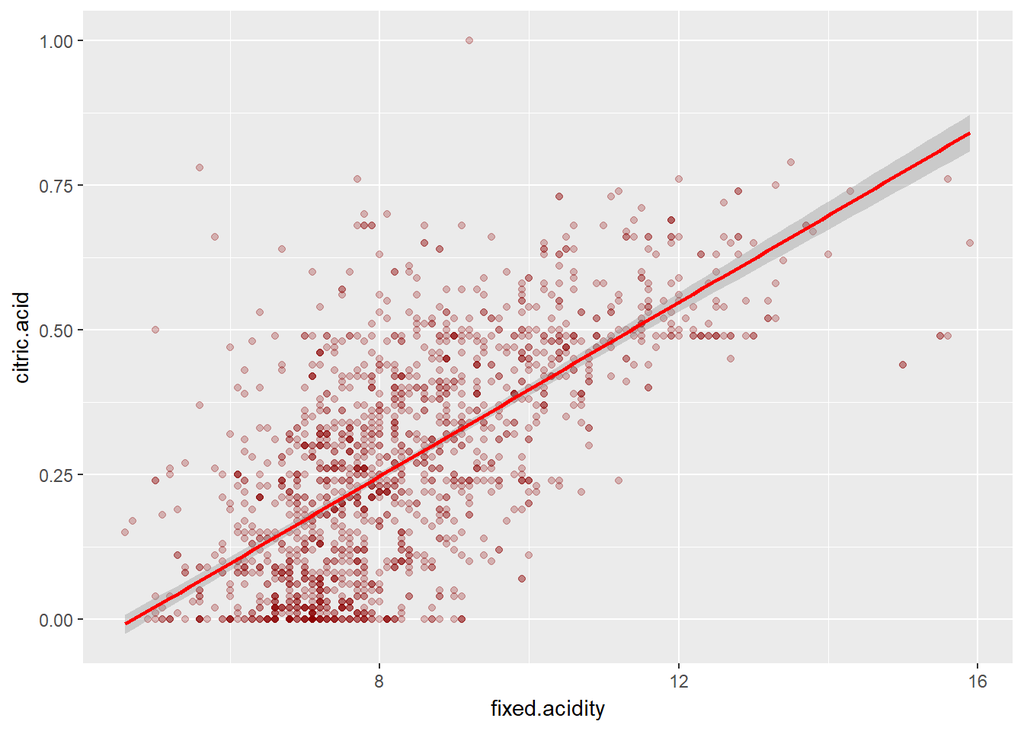

We can see a strong postive corealtion between these citric acid and fixed acidity.

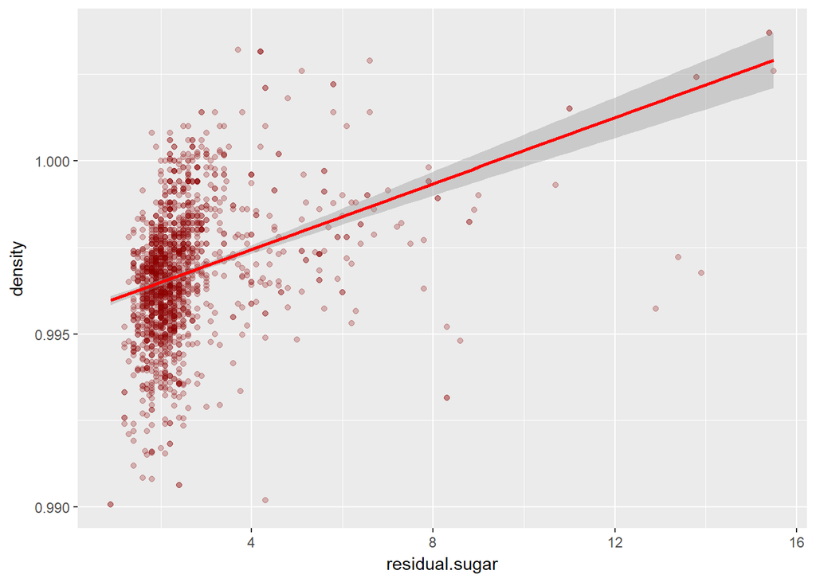

We see some positive corelation between residual sugar and density.

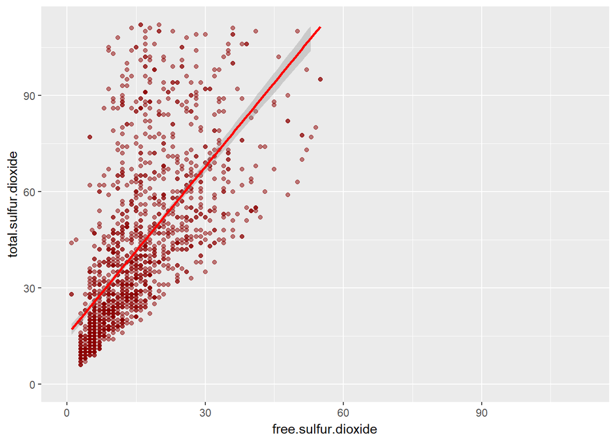

From the above plot, it seems both are positively correlated.

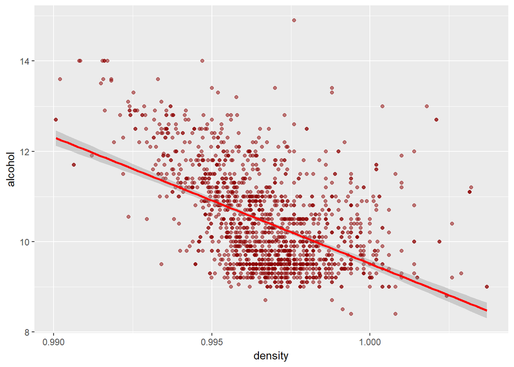

We can infer that there is negative correlation between density and alcohol.

# Bivariate Analysis

### Talk about some of the relationships you observed in this part of the investigation.

The alcohol has a corelation with the quality of wine. Alcohol content increases with the increase in quality of wine.

There are also other variables which has an impact on the quality of wines.

The mean of volatile acidity decreases with higher quality of wines.

The mean of sulphate is increases as quality of wine gets better.

The mean of Citric acid increases with increase in quality of wines.

### Did you observe any interesting relationships between the other features (not the main feature(s) of interest)?

The fixed acidity and pH are negatively corelated.

The fixed acidity and citric acid also corelates with each other which makes sense as citric acid is also a non-volatile acid. with increase in acidity generally makes the ph value decrease as 0 ph value has the most acidity in it.

Density and alcohol are negatively corelated.

### What was the strongest relationship you found?

The strongest relationship I found was between quality and alcohol.

# Multivariate Plots Section

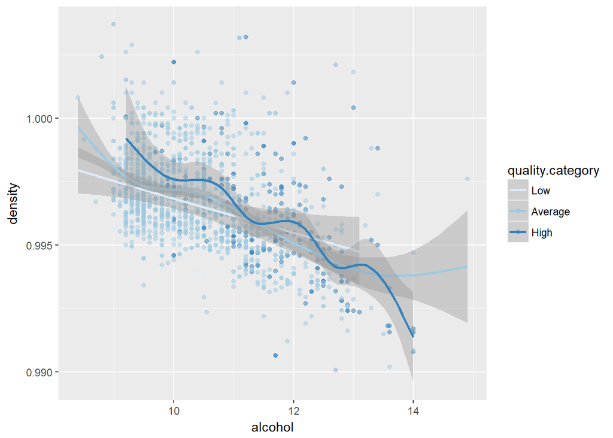

From the above plot, the regression line with better quality seems to jumble up as the alcohol increases in the wine. We can see that high wines usually consist of high alcohol with low density.

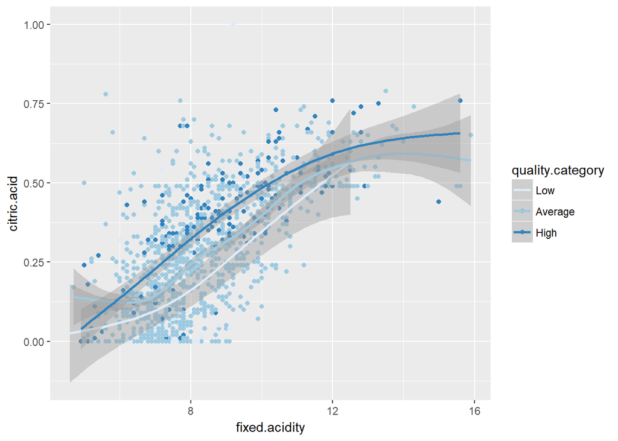

We can see that thre is a linear relationship between higher citric acid and fixed acidity. High quality seems to have higher values of both of these variables.

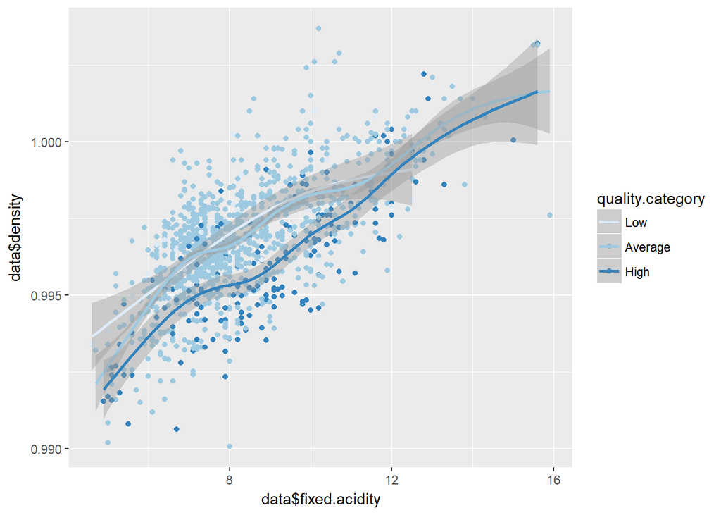

We can see that density of wine increases with the fixed acidity irrespective of qualitty of wines.

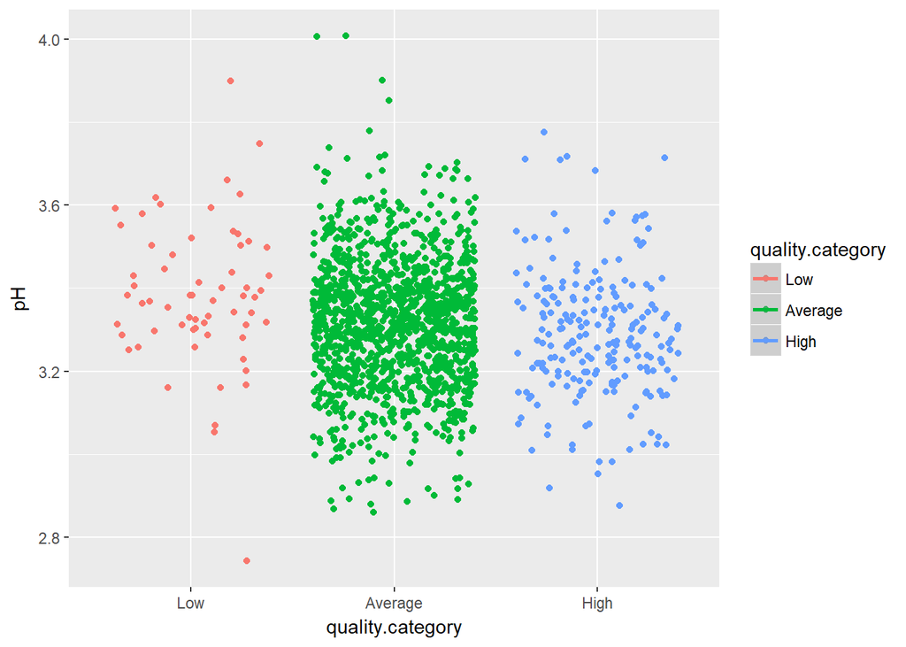

```
##
## Call:
## lm(formula = quality ~ alcohol + sulphates + pH + residual.sugar +
##     chlorides + total.sulfur.dioxide, data = data)
##
## Residuals:
##      Min       1Q   Median       3Q      Max
## -2.60979 -0.38487 -0.05857  0.47000  1.95671
##
## Coefficients:
##                        Estimate Std. Error t value Pr(>|t|)
## (Intercept)           4.3795842  0.4144106  10.568  < 2e-16 ***
## alcohol               0.3206922  0.0172037  18.641  < 2e-16 ***
## sulphates             1.1811214  0.1101203  10.726  < 2e-16 ***
## pH                   -0.7588198  0.1156594  -6.561 7.22e-11 ***
## residual.sugar        0.0081097  0.0122741   0.661    0.509
## chlorides            -2.7661785  0.4052075  -6.827 1.23e-11 ***
## total.sulfur.dioxide -0.0027888  0.0005349  -5.213 2.10e-07 ***
## ---
## Signif. codes:  0 '***' 0.001 '**' 0.01 '*' 0.05 '.' 0.1 ' ' 1
##
## Residual standard error: 0.67 on 1592 degrees of freedom
## Multiple R-squared:  0.3142, Adjusted R-squared:  0.3116
## F-statistic: 121.6 on 6 and 1592 DF,  p-value: < 2.2e-16
```

# Multivariate Analysis

We examinedn relationships of quality and between variables like alcohol, Citric acid, density, and pH.

## The R-squared value is 0.3142 which explains seems to explain 31% of variance in the quality of wines.

# Final Plots and Summary

### Plot One

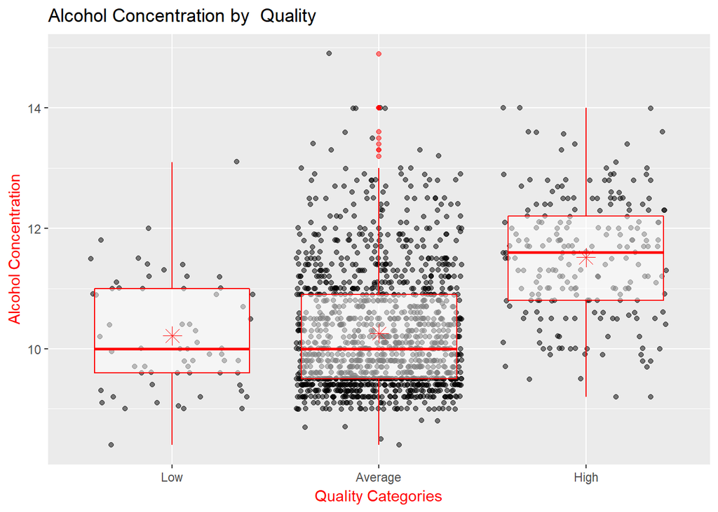

### Plot Two

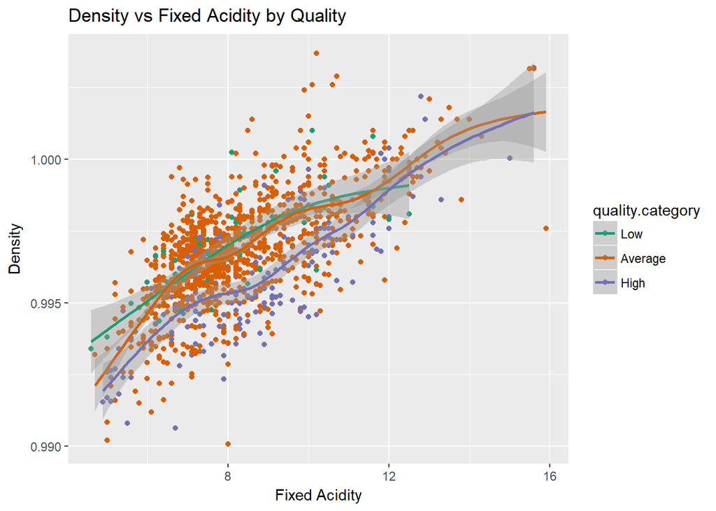

### Description Two

We can see that Density of wine is postively corelated with Fixed acidity. Density of wine increases with the fixed acidity irrespective of quality of wines.

### Plot Three

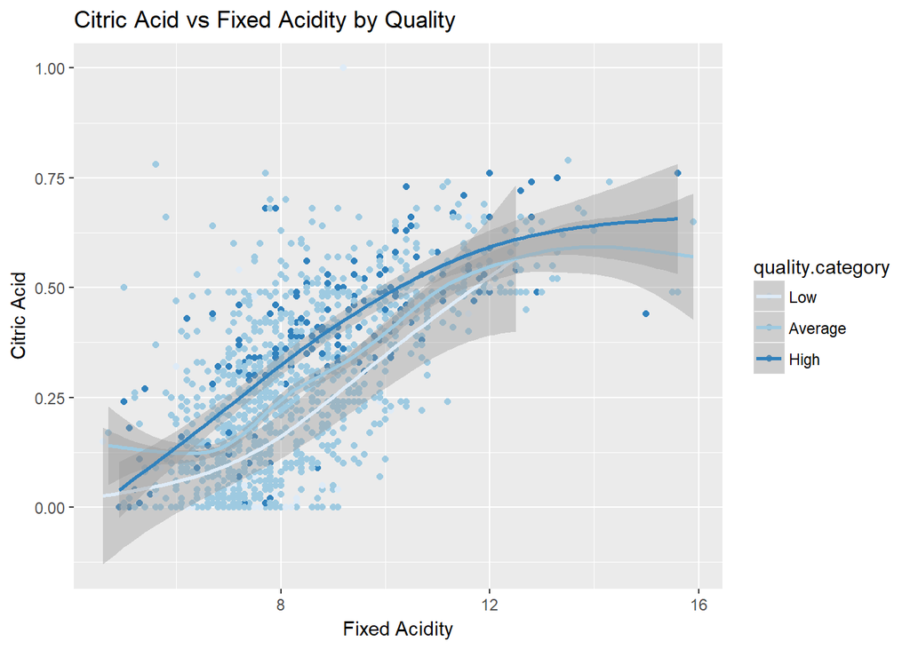

### Description Three

Citric acid seems to be influential on the quality of wines after alcohol. Based on my research, I found that citric acid is added less frequently and is added to a limit. Moreover, it can also be used for removing excess iron and copper from the wine if potassium ferrocyanide is not available. So as we do not know about the location of the wine source , we can say that this might be the reason for increased use in red wines.

# Reflection

There were 11 variables in the dataset. I examined all the variables with the quality of wines. I also tried to find out any interesting relationships among these variables.

There was not the much strong relationship between the variables and the quality of wine as you would expect.

As discussed above multiple times, alcohol seems to have the most influential variable in the quality of wines.

Apart from sulphates, the surprising variable was a Citric acid which seems to have a good relationship with quality of wines.

I tried to explore the dataset and relationships as much as possible but I felt that if more data such as the geographic location of the wine and testers would have been available then more exploration could have been possible. The reason is that that wines from different locations are being perceived differently by people and have their own characteristics.

For future work, we can use advanced regression methods or classfier models to assess the vaiables which are important to determine the quality of wines.